# Lending Club Loan Data Analysis

### 2c. How key factors relate to default

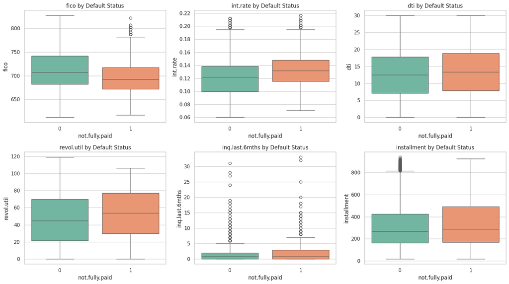

```python
fig, axes = plt.subplots(2, 3, figsize=(16, 9))
compare_features = ['fico', 'int.rate', 'dti', 'revol.util', 'inq.last.6mths', 'installment']
for ax, col in zip(axes.flatten(), compare_features):
    sns.boxplot(data=df, x='not.fully.paid', y=col, hue='not.fully.paid', ax=ax, palette='Set2', legend=False)
    ax.set_title(f'{col} by Default Status')
    ax.set_xlabel('not.fully.paid')
plt.tight_layout()
plt.savefig('lc_factors_by_default.png', dpi=120)
plt.show()
```

**Reading:** loans that were **not fully paid** tend to have noticeably **lower `fico` scores**, **higher `int.rate`** (consistent with LendingClub's own risk-based pricing — riskier borrowers are charged more), and somewhat **higher `inq.last.6mths`** (more recent credit inquiries, a common early-warning signal of financial stress). `dti` and `revol.util` show a similar but weaker pattern.

### 2d. Default rate by loan purpose and by credit policy

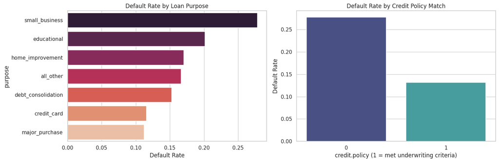

```
purpose
small_business        0.277868
educational           0.201166
home_improvement      0.170111
all_other             0.166023
debt_consolidation    0.152388
credit_card           0.115689
major_purchase        0.112128
Name: not.fully.paid, dtype: float64

credit.policy
0    0.277837
1    0.131518
Name: not.fully.paid, dtype: float64
```

```python
fig, axes = plt.subplots(1, 2, figsize=(15, 5))

purpose_default = df.groupby('purpose')['not.fully.paid'].mean().sort_values(ascending=False)
sns.barplot(x=purpose_default.values, y=purpose_default.index, hue=purpose_default.index,
            ax=axes[0], palette='rocket', legend=False)
axes[0].set_title('Default Rate by Loan Purpose')
axes[0].set_xlabel('Default Rate')

policy_default = df.groupby('credit.policy')['not.fully.paid'].mean()
sns.barplot(x=policy_default.index.astype(str), y=policy_default.values, hue=policy_default.index.astype(str),
            ax=axes[1], palette='mako', legend=False)
axes[1].set_title('Default Rate by Credit Policy Match')
axes[1].set_xlabel('credit.policy (1 = met underwriting criteria)')
axes[1].set_ylabel('Default Rate')

plt.tight_layout()
plt.savefig('lc_default_by_purpose_policy.png', dpi=120)
plt.show()

print(purpose_default)
print()
print(policy_default)
```

**Reading:** `small_business` loans default at a noticeably higher rate than other purposes — consistent with small businesses being a higher-risk lending category generally. As expected, loans that **did not** meet LendingClub's own credit-policy criteria (`credit.policy = 0`) default at a substantially higher rate than those that did, which is a good sanity check that the existing underwriting signal is meaningful.

## 3. Additional Feature Engineering — Correlation-Based Feature Reduction

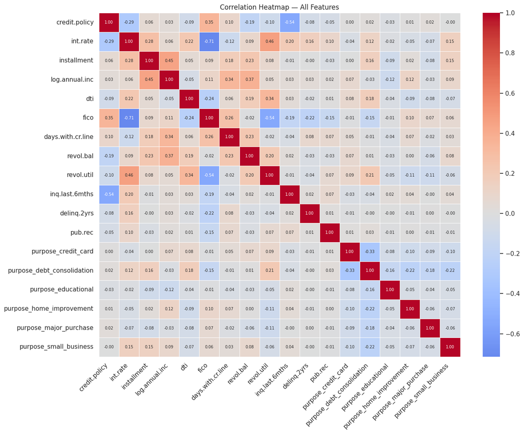

```python
corr_matrix = df_transformed.drop(columns=['not.fully.paid']).corr()

plt.figure(figsize=(14, 11))
sns.heatmap(corr_matrix, annot=True, fmt='.2f', cmap='coolwarm', center=0, linewidths=0.4,
            annot_kws={'size': 7})
plt.title('Correlation Heatmap — All Features')
plt.xticks(rotation=45, ha='right')
plt.tight_layout()
plt.savefig('lc_correlation_heatmap.png', dpi=120)
plt.show()
```

```python
# Identify pairs of features with strong correlation (|r| > 0.7), a common threshold for
# flagging problematic multicollinearity before modeling
strong_corr_pairs = []
for i in range(len(corr_matrix.columns)):
    for j in range(i):
        val = corr_matrix.iloc[i, j]
        if abs(val) > 0.7:
            strong_corr_pairs.append((corr_matrix.columns[i], corr_matrix.columns[j], round(val, 3)))

print("Feature pairs with |correlation| > 0.7:")
for pair in strong_corr_pairs:
    print(pair)
```

```
Feature pairs with |correlation| > 0.7:
('fico', 'int.rate', np.float64(-0.715))
```

**Finding:** only one feature pair exceeds the |r| > 0.7 threshold: **`fico`** and **`int.rate`** (r = -0.715) — which makes intuitive sense, since LendingClub explicitly prices interest rates based on the borrower's credit risk, and FICO score is a primary input to that risk assessment. Since these two variables are largely encoding the same underlying risk signal, we drop the one with the weaker individual correlation to the target (`not.fully.paid`) and keep the other, avoiding redundant signal being fed into the network twice.

```python
# Drop the more redundant member of each strongly-correlated pair (keeping the more directly interpretable one)
cols_to_drop = []
for f1, f2, corr_val in strong_corr_pairs:
    # keep whichever of the two has a stronger individual correlation with the target
    target_corr_f1 = abs(df_transformed[f1].corr(df_transformed['not.fully.paid']))
    target_corr_f2 = abs(df_transformed[f2].corr(df_transformed['not.fully.paid']))
    drop_col = f2 if target_corr_f1 >= target_corr_f2 else f1
    if drop_col not in cols_to_drop:
        cols_to_drop.append(drop_col)

print(f"Dropping {len(cols_to_drop)} redundant feature(s): {cols_to_drop}")

df_final = df_transformed.drop(columns=cols_to_drop)
print(f"Final feature set shape: {df_final.shape}")
```

```
Dropping 1 redundant feature(s): ['fico']
Final feature set shape: (9578, 18)
```